# Ejercicio: DataSet Toyota Corolla

Alvarez Ignacio Nicolas

9/2019

## Ejercicio: DataSet Toyota

Este ejercicio consiste en realizar un análisis exploratorio sobre un dataset de vehiculos Toyota Corolla con 1436 instancias y 37 atributos.

El objetivo es conseguir una regresión lineal con un resultado aceptable interpretando cada paso del razonamiento necesario para llegar al objetivo.

```r
library(tidyverse)
library(fastDummies) # libreria para encoding
library(car)
```

```r
library(corrplot) # lbreria para ver la correlacion entre variables
```

### Lectura del DataSet:

```r
raw_data = read_csv("ToyotaCorolla.csv")
```

### Estructura del DataSet:

- El atributo objetivo es Price.

```r
str(raw_data)
```

```
## Classes 'spec_tbl_df', 'tbl_df', 'tbl' and 'data.frame': 1436 obs. of  37 variables:
##  $ Id              : num  1 2 3 4 5 6 7 8 9 10 ...
##  $ Model           : chr  "TOYOTA Corolla 2.0 D4D HATCHB TERRA 2/3-Doors" "TOYOTA Corolla 2.0 D4D HATCHB TERRA 2/3-Doors" "?TOYOTA Corolla 2.0 D4D HATCHB TERRA 2/3-Doors" "TOYOTA Corolla 2.0 D4D HATCHB TERRA 2/3-Doors" ...
##  $ Price           : num  13500 13750 13950 14950 13750 ...
##  $ Age_08_04       : num  23 23 24 26 30 32 27 30 27 23 ...
##  $ Mfg_Month       : num  10 10 9 7 3 1 6 3 6 10 ...
##  $ Mfg_Year        : num  2002 2002 2002 2002 2002 ...
##  $ KM              : num  46986 72937 41711 48000 38500 ...
##  $ Fuel_Type       : chr  "Diesel" "Diesel" "Diesel" "Diesel" ...
##  $ HP              : num  90 90 90 90 90 90 90 90 192 69 ...
##  $ Met_Color       : num  1 1 1 0 0 0 1 1 0 0 ...
##  $ Automatic       : num  0 0 0 0 0 0 0 0 0 0 ...
##  $ cc              : num  2000 2000 2000 2000 2000 2000 2000 2000 1800 1900 ...
##  $ Doors           : num  3 3 3 3 3 3 3 3 3 3 ...
##  $ Cylinders       : num  4 4 4 4 4 4 4 4 4 4 ...
##  $ Gears           : num  5 5 5 5 5 5 5 5 5 5 ...
##  $ Quarterly_Tax   : num  210 210 210 210 210 210 210 210 100 185 ...
##  $ Weight          : num  1165 1165 1165 1165 1170 ...
##  $ Mfr_Guarantee   : num  0 0 1 1 1 0 0 1 0 0 ...
##  $ BOVAG_Guarantee : num  1 1 1 1 1 1 1 1 1 1 ...
##  $ Guarantee_Period: num  3 3 3 3 3 3 3 3 3 3 ...
##  $ ABS             : num  1 1 1 1 1 1 1 1 1 1 ...
##  $ Airbag_1        : num  1 1 1 1 1 1 1 1 1 1 ...
##  $ Airbag_2        : num  1 1 1 1 1 1 1 1 0 1 ...
##  $ Airco           : num  0 1 0 0 1 1 1 1 1 1 ...
##  $ Automatic_airco : num  0 0 0 0 0 0 0 0 0 0 ...
##  $ Boardcomputer   : num  1 1 1 1 1 1 1 1 0 1 ...
##  $ CD_Player       : num  0 1 0 0 0 0 0 1 0 0 ...
##  $ Central_Lock    : num  1 1 0 0 1 1 1 1 1 0 ...
##  $ Powered_Windows : num  1 0 0 0 1 1 1 1 1 0 ...
##  $ Power_Steering  : num  1 1 1 1 1 1 1 1 1 1 ...
##  $ Radio           : num  0 0 0 0 0 0 0 0 1 0 ...
##  $ Mistlamps       : num  0 0 0 0 1 1 0 0 0 0 ...
##  $ Sport_Model     : num  0 0 0 0 0 0 1 0 0 0 ...
##  $ Backseat_Divider: num  1 1 1 1 1 1 1 1 0 1 ...
##  $ Metallic_Rim    : num  0 0 0 0 0 0 0 0 1 0 ...
##  $ Radio_cassette  : num  0 0 0 0 0 0 0 0 1 0 ...
##  $ Tow_Bar         : num  0 0 0 0 0 0 0 0 0 0 ...
##  - attr(*, "spec")=
##   .. cols(
```

[output cut: 23 more lines]

```
##   ..   Airco = col_double(),
##   ..   Automatic_airco = col_double(),
##   ..   Boardcomputer = col_double(),
##   ..   CD_Player = col_double(),
##   ..   Central_Lock = col_double(),
##   ..   Powered_Windows = col_double(),
##   ..   Power_Steering = col_double(),
##   ..   Radio = col_double(),
##   ..   Mistlamps = col_double(),
##   ..   Sport_Model = col_double(),
##   ..   Backseat_Divider = col_double(),
##   ..   Metallic_Rim = col_double(),
##   ..   Radio_cassette = col_double(),
##   ..   Tow_Bar = col_double()
##   .. )
```

**El dataset esta conformado 1436 observaciones correspondientes a vehiculos Toyota Corolla.**

En el resumen de los datos se observan en primera instancia las siguientes consideraciones:

- El valor maximo de cc es de 16000, demasiado alto considerando la media.
- El atributo Fuel_Type es de tipo char, requerira un proceso de encoding.
- El valor de Cylinder es constante.

```r
summary(raw_data)
```

```
##        Id            Model               Price         Age_08_04
##  Min.   :   1.0   Length:1436        Min.   : 4350   Min.   : 1.00
##  1st Qu.: 361.8   Class :character   1st Qu.: 8450   1st Qu.:44.00
##  Median : 721.5   Mode  :character   Median : 9900   Median :61.00
##  Mean   : 721.6                      Mean   :10731   Mean   :55.95
##  3rd Qu.:1081.2                      3rd Qu.:11950   3rd Qu.:70.00
##  Max.   :1442.0                      Max.   :32500   Max.   :80.00
##    Mfg_Month         Mfg_Year          KM          Fuel_Type
##  Min.   : 1.000   Min.   :1998   Min.   :     1   Length:1436
##  1st Qu.: 3.000   1st Qu.:1998   1st Qu.: 43000   Class :character
##  Median : 5.000   Median :1999   Median : 63390   Mode  :character
##  Mean   : 5.549   Mean   :2000   Mean   : 68533
##  3rd Qu.: 8.000   3rd Qu.:2001   3rd Qu.: 87021
##  Max.   :12.000   Max.   :2004   Max.   :243000
##        HP          Met_Color        Automatic             cc
##  Min.   : 69.0   Min.   :0.0000   Min.   :0.00000   Min.   : 1300
##  1st Qu.: 90.0   1st Qu.:0.0000   1st Qu.:0.00000   1st Qu.: 1400
##  Median :110.0   Median :1.0000   Median :0.00000   Median : 1600
##  Mean   :101.5   Mean   :0.6748   Mean   :0.05571   Mean   : 1577
##  3rd Qu.:110.0   3rd Qu.:1.0000   3rd Qu.:0.00000   3rd Qu.: 1600
##  Max.   :192.0   Max.   :1.0000   Max.   :1.00000   Max.   :16000
##      Doors         Cylinders     Gears       Quarterly_Tax
##  Min.   :2.000   Min.   :4   Min.   :3.000   Min.   : 19.00
##  1st Qu.:3.000   1st Qu.:4   1st Qu.:5.000   1st Qu.: 69.00
##  Median :4.000   Median :4   Median :5.000   Median : 85.00
##  Mean   :4.033   Mean   :4   Mean   :5.026   Mean   : 87.12
##  3rd Qu.:5.000   3rd Qu.:4   3rd Qu.:5.000   3rd Qu.: 85.00
##  Max.   :5.000   Max.   :4   Max.   :6.000   Max.   :283.00
##      Weight     Mfr_Guarantee    BOVAG_Guarantee  Guarantee_Period
##  Min.   :1000   Min.   :0.0000   Min.   :0.0000   Min.   : 3.000
##  1st Qu.:1040   1st Qu.:0.0000   1st Qu.:1.0000   1st Qu.: 3.000
##  Median :1070   Median :0.0000   Median :1.0000   Median : 3.000
##  Mean   :1072   Mean   :0.4095   Mean   :0.8955   Mean   : 3.815
##  3rd Qu.:1085   3rd Qu.:1.0000   3rd Qu.:1.0000   3rd Qu.: 3.000
##  Max.   :1615   Max.   :1.0000   Max.   :1.0000   Max.   :36.000
##       ABS            Airbag_1         Airbag_2          Airco
##  Min.   :0.0000   Min.   :0.0000   Min.   :0.0000   Min.   :0.0000
##  1st Qu.:1.0000   1st Qu.:1.0000   1st Qu.:0.0000   1st Qu.:0.0000
##  Median :1.0000   Median :1.0000   Median :1.0000   Median :1.0000
##  Mean   :0.8134   Mean   :0.9708   Mean   :0.7228   Mean   :0.5084
```

[output cut: 15 more lines]

```
##  Max.   :1.000   Max.   :1.0000   Max.   :1.0000   Max.   :1.000
##   Sport_Model     Backseat_Divider  Metallic_Rim    Radio_cassette
##  Min.   :0.0000   Min.   :0.0000   Min.   :0.0000   Min.   :0.0000
##  1st Qu.:0.0000   1st Qu.:1.0000   1st Qu.:0.0000   1st Qu.:0.0000
##  Median :0.0000   Median :1.0000   Median :0.0000   Median :0.0000
##  Mean   :0.3001   Mean   :0.7702   Mean   :0.2047   Mean   :0.1455
##  3rd Qu.:1.0000   3rd Qu.:1.0000   3rd Qu.:0.0000   3rd Qu.:0.0000
##  Max.   :1.0000   Max.   :1.0000   Max.   :1.0000   Max.   :1.0000
##     Tow_Bar
##  Min.   :0.0000
##  1st Qu.:0.0000
##  Median :0.0000
##  Mean   :0.2779
##  3rd Qu.:1.0000
##  Max.   :1.0000
```

### Lectura General del DataSet:

```r
head(raw_data)
```

```
## # A tibble: 6 x 37
##      Id Model Price Age_08_04 Mfg_Month Mfg_Year    KM Fuel_Type    HP
##   <dbl> <chr> <dbl>     <dbl>     <dbl>    <dbl> <dbl> <chr>     <dbl>
## 1     1 TOYO~ 13500        23        10     2002 46986 Diesel       90
## 2     2 TOYO~ 13750        23        10     2002 72937 Diesel       90
## 3     3 ?TOY~ 13950        24         9     2002 41711 Diesel       90
## 4     4 TOYO~ 14950        26         7     2002 48000 Diesel       90
## 5     5 TOYO~ 13750        30         3     2002 38500 Diesel       90
## 6     6 TOYO~ 12950        32         1     2002 61000 Diesel       90
## # ... with 28 more variables: Met_Color <dbl>, Automatic <dbl>, cc <dbl>,
## #   Doors <dbl>, Cylinders <dbl>, Gears <dbl>, Quarterly_Tax <dbl>,
## #   Weight <dbl>, Mfr_Guarantee <dbl>, BOVAG_Guarantee <dbl>,
## #   Guarantee_Period <dbl>, ABS <dbl>, Airbag_1 <dbl>, Airbag_2 <dbl>,
## #   Airco <dbl>, Automatic_airco <dbl>, Boardcomputer <dbl>,
## #   CD_Player <dbl>, Central_Lock <dbl>, Powered_Windows <dbl>,
## #   Power_Steering <dbl>, Radio <dbl>, Mistlamps <dbl>, Sport_Model <dbl>,
## #   Backseat_Divider <dbl>, Metallic_Rim <dbl>, Radio_cassette <dbl>,
## #   Tow_Bar <dbl>
```

```r
tail(raw_data)
```

```
## # A tibble: 6 x 37
##      Id Model Price Age_08_04 Mfg_Month Mfg_Year    KM Fuel_Type    HP
##   <dbl> <chr> <dbl>     <dbl>     <dbl>    <dbl> <dbl> <chr>     <dbl>
## 1  1437 TOYO~  8450        80         1     1998 23000 Petrol       86
## 2  1438 TOYO~  7500        69        12     1998 20544 Petrol       86
## 3  1439 TOYO~ 10845        72         9     1998 19000 Petrol       86
## 4  1440 TOYO~  8500        71        10     1998 17016 Petrol       86
## 5  1441 TOYO~  7250        70        11     1998 16916 Petrol       86
## 6  1442 TOYO~  6950        76         5     1998     1 Petrol      110
## # ... with 28 more variables: Met_Color <dbl>, Automatic <dbl>, cc <dbl>,
## #   Doors <dbl>, Cylinders <dbl>, Gears <dbl>, Quarterly_Tax <dbl>,
## #   Weight <dbl>, Mfr_Guarantee <dbl>, BOVAG_Guarantee <dbl>,
## #   Guarantee_Period <dbl>, ABS <dbl>, Airbag_1 <dbl>, Airbag_2 <dbl>,
## #   Airco <dbl>, Automatic_airco <dbl>, Boardcomputer <dbl>,
## #   CD_Player <dbl>, Central_Lock <dbl>, Powered_Windows <dbl>,
## #   Power_Steering <dbl>, Radio <dbl>, Mistlamps <dbl>, Sport_Model <dbl>,
## #   Backseat_Divider <dbl>, Metallic_Rim <dbl>, Radio_cassette <dbl>,
## #   Tow_Bar <dbl>
```

### Análisis exploratorio: Boxplot:

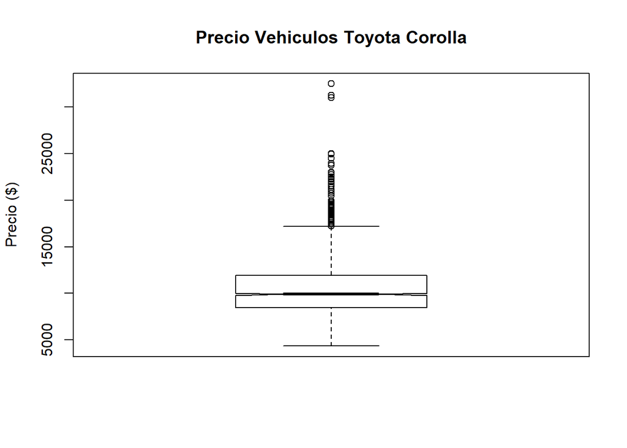

```r
par(mfrow=c(1,1))
boxplot(raw_data$Price,main = "Precio Vehiculos Toyota Corolla",
        ylab = "Precio ($)", notch = TRUE)
```

- Tras una investigación en medios externos al dataset, se comprobó que el precio de los outliers correspondientes al modelo TOYOTA Corolla VERSO 2.0 D4D SOL (7) MPV, es un dato correcto.

```r
df_valores_precio_extremo <- subset(raw_data, raw_data$Price > 25000)
df_valores_precio_extremo
```

```
## # A tibble: 3 x 37
##      Id Model Price Age_08_04 Mfg_Month Mfg_Year    KM Fuel_Type    HP
##   <dbl> <chr> <dbl>     <dbl>     <dbl>    <dbl> <dbl> <chr>     <dbl>
## 1   111 ?TOY~ 32500         4         5     2004     1 Diesel      116
## 2   112 TOYO~ 31000         4         5     2004  4000 Diesel      116
## 3   113 TOYO~ 31275         4         5     2004  1500 Diesel      116
## # ... with 28 more variables: Met_Color <dbl>, Automatic <dbl>, cc <dbl>,
## #   Doors <dbl>, Cylinders <dbl>, Gears <dbl>, Quarterly_Tax <dbl>,
## #   Weight <dbl>, Mfr_Guarantee <dbl>, BOVAG_Guarantee <dbl>,
## #   Guarantee_Period <dbl>, ABS <dbl>, Airbag_1 <dbl>, Airbag_2 <dbl>,
## #   Airco <dbl>, Automatic_airco <dbl>, Boardcomputer <dbl>,
## #   CD_Player <dbl>, Central_Lock <dbl>, Powered_Windows <dbl>,
## #   Power_Steering <dbl>, Radio <dbl>, Mistlamps <dbl>, Sport_Model <dbl>,
## #   Backseat_Divider <dbl>, Metallic_Rim <dbl>, Radio_cassette <dbl>,
## #   Tow_Bar <dbl>
```

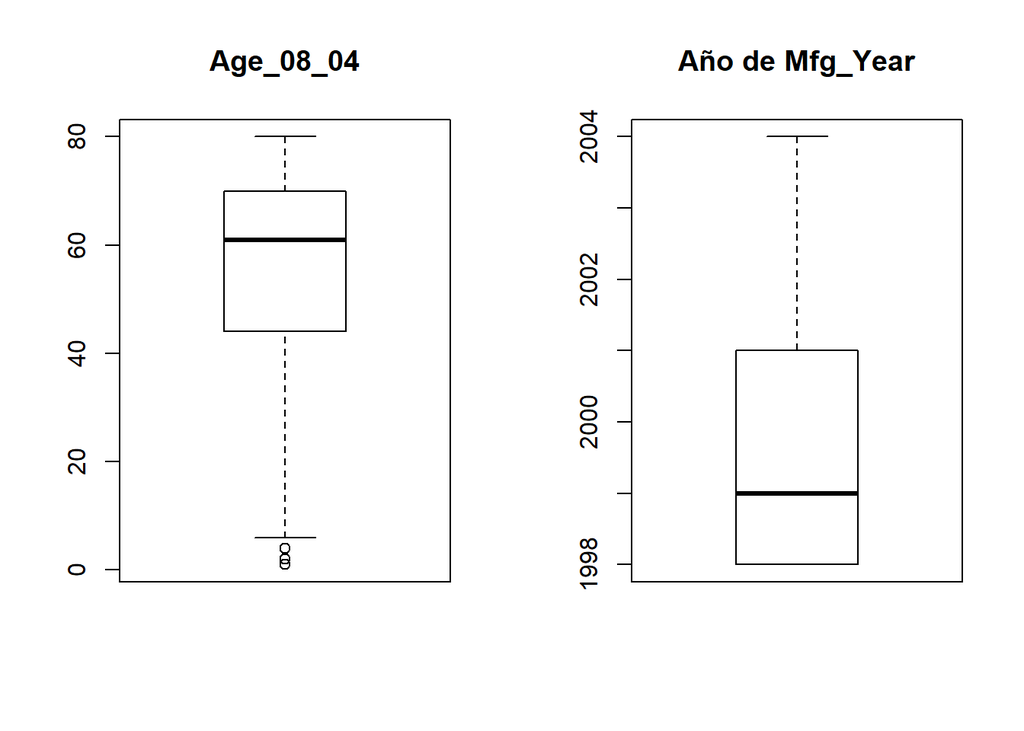

```r
par(mfrow=c(1,2))

boxplot(raw_data$Age_08_04,main = "Age_08_04")
boxplot(raw_data$Mfg_Year,main = "Año de Mfg_Year")
```

- El atributo “HP” presenta un valor outlier superior a 180. Según una investigacion realizada en medios externos al dataset, el valor si corresponde a un modelo de Toyota Corolla.
- El atributo “KM” presenta valores outliers. Destaco sobretodo un conjunto de valores superiores a los 200000.

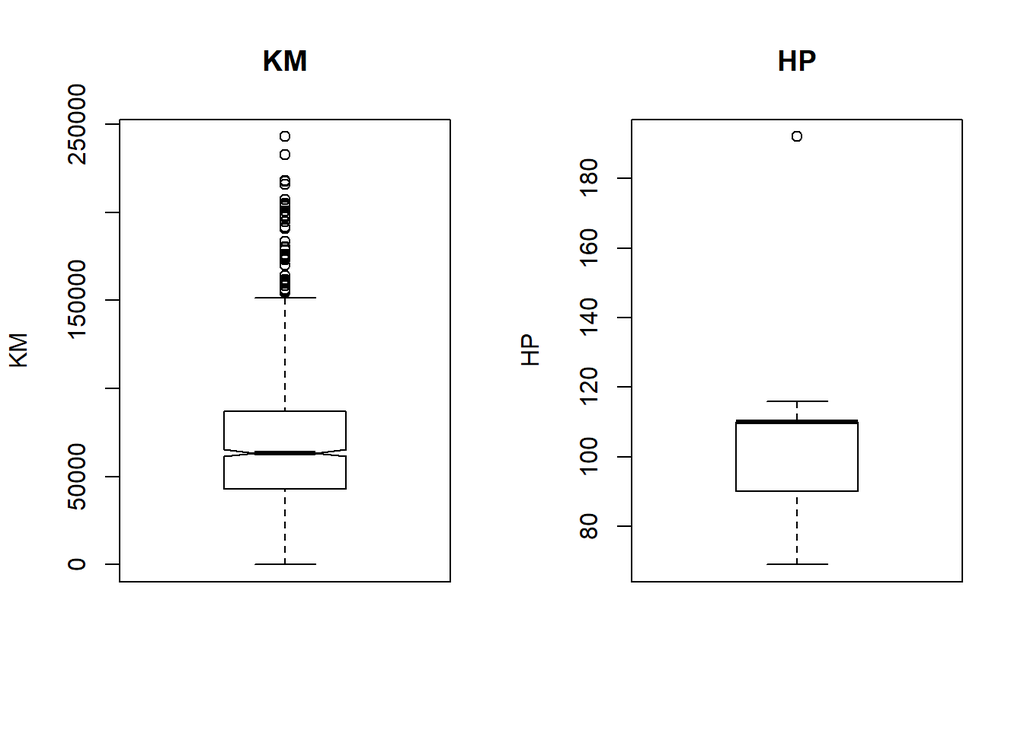

```r
par(mfrow=c(1,2))

boxplot(raw_data$KM,main = "KM",
        ylab = "KM", notch = TRUE)

boxplot(raw_data$HP,main = "HP",
        ylab = "HP", notch = FALSE)
```

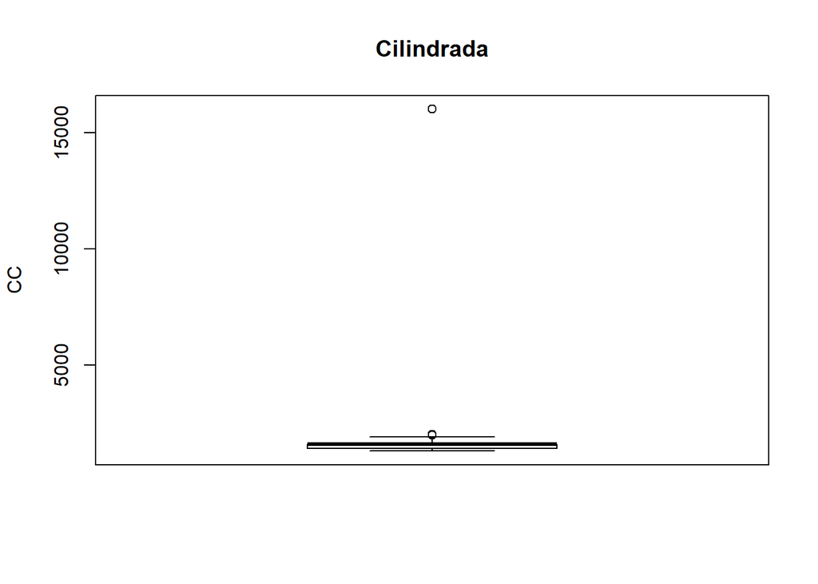

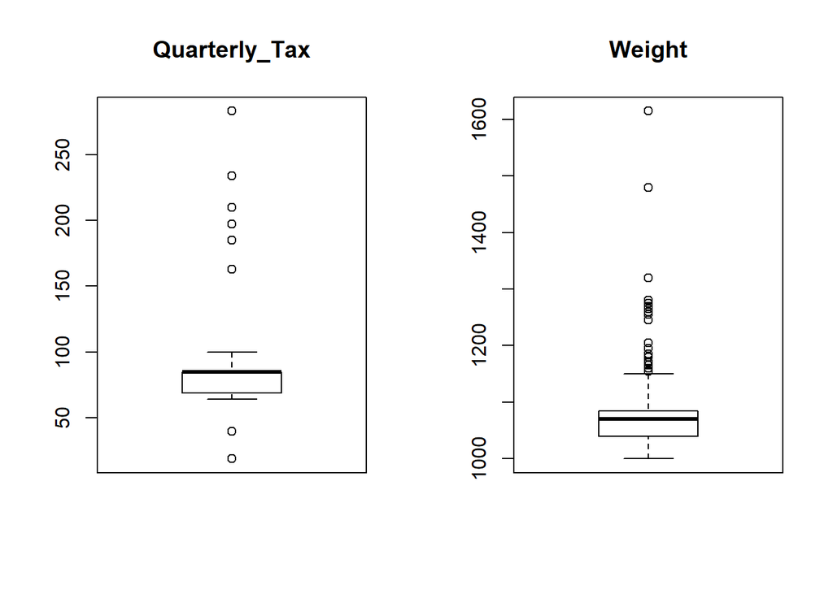

```r
par(mfrow=c(1,2))

boxplot(raw_data$Quarterly_Tax, main="Quarterly_Tax")
boxplot(raw_data$Weight, main="Weight")
```

```r
df0 <-  raw_data
```

## Análisis exploratorio: Pie

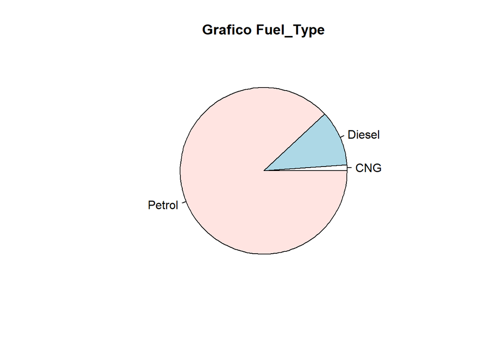

```r
valur = table(df0$Fuel_Type)
pie(x = valur, main="Grafico Fuel_Type")
```

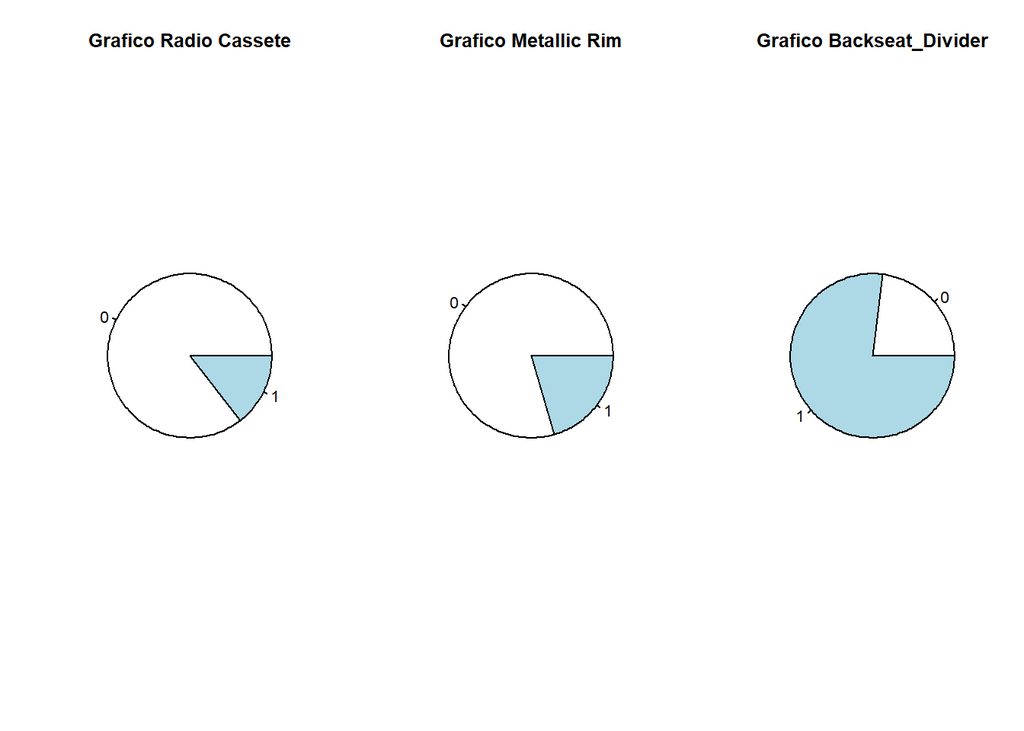

```r
par(mfrow=c(1,3))

valur = table(df0$Radio_cassette)
pie(x = valur, main="Grafico Radio Cassete")

valur = table(df0$Metallic_Rim)
pie(x = valur, main="Grafico Metallic Rim")

valur = table(df0$Backseat_Divider)
pie(x = valur, main="Grafico Backseat_Divider")
```

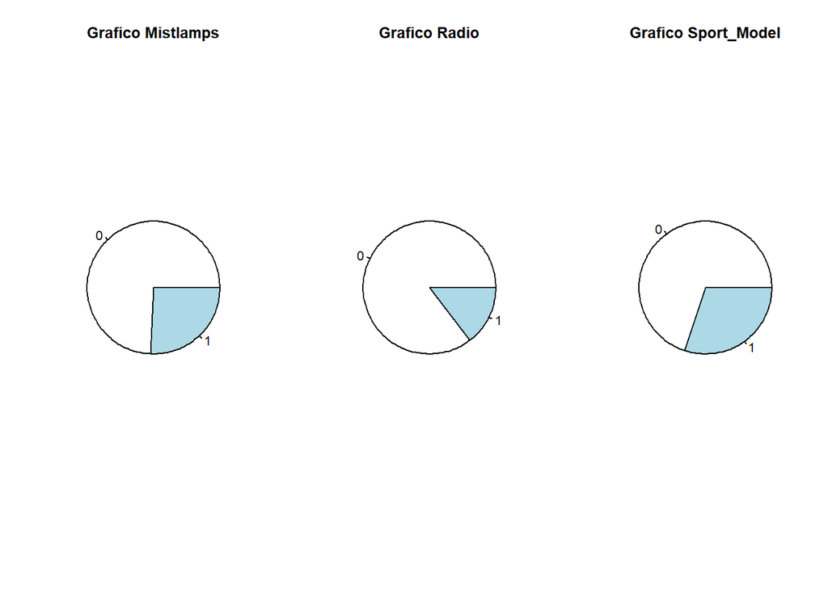

```r
par(mfrow=c(1,3))

valur = table(df0$Mistlamps)
pie(x = valur, main="Grafico Mistlamps")

valur = table(df0$Radio)
pie(x = valur, main="Grafico Radio")

valur = table(df0$Sport_Model)
pie(x = valur, main="Grafico Sport_Model")
```

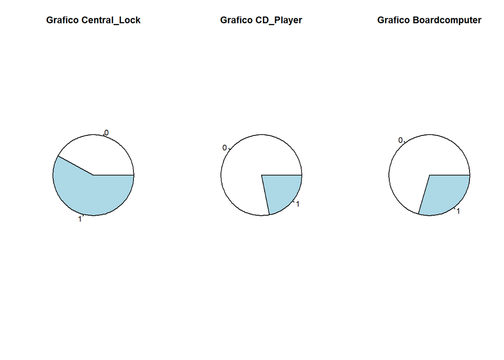

```r
par(mfrow=c(1,3))

valur = table(df0$Central_Lock)
pie(x = valur, main="Grafico Central_Lock")

valur = table(df0$CD_Player) # esto no se usa
pie(x = valur, main="Grafico CD_Player")

valur = table(df0$Boardcomputer)
pie(x = valur, main="Grafico Boardcomputer")
```

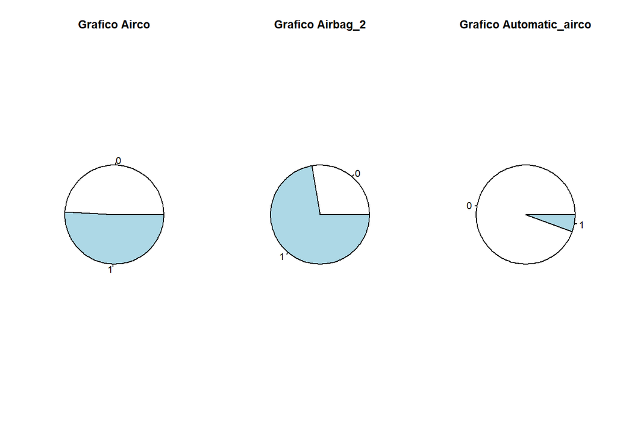

```r
par(mfrow=c(1,3))

valur = table(df0$Airco)
pie(x = valur, main="Grafico Airco")

valur = table(df0$Airbag_2)
pie(x = valur, main="Grafico Airbag_2")

valur = table(df0$Automatic_airco)
pie(x = valur, main="Grafico Automatic_airco")
```

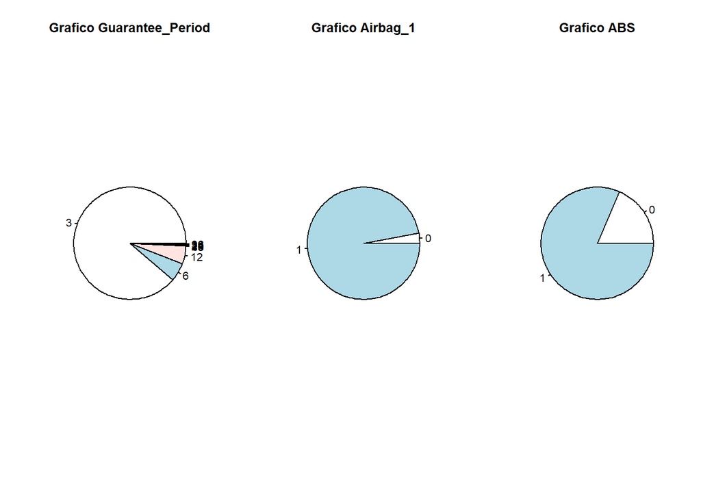

```r
par(mfrow=c(1,3))

valur = table(df0$Guarantee_Period)
pie(x = valur, main="Grafico Guarantee_Period")

valur = table(df0$Airbag_1)
pie(x = valur, main="Grafico Airbag_1")

valur = table(df0$ABS)
pie(x = valur, main="Grafico ABS")
```

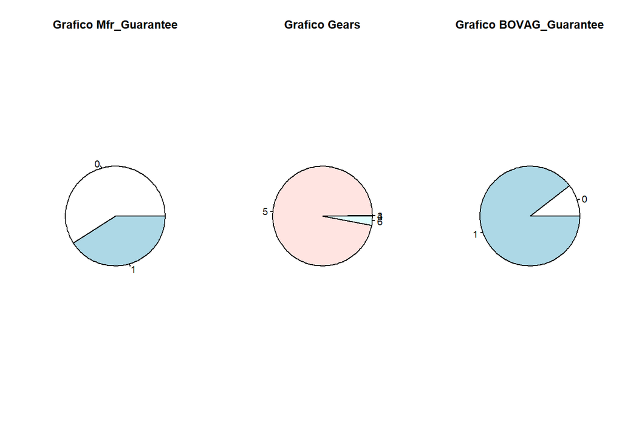

```r
par(mfrow=c(1,3))

valur = table(df0$Mfr_Guarantee)
pie(x = valur, main="Grafico Mfr_Guarantee")

valur = table(df0$Gears)
pie(x = valur, main="Grafico Gears")

valur = table(df0$BOVAG_Guarantee)
pie(x = valur, main="Grafico BOVAG_Guarantee")
```

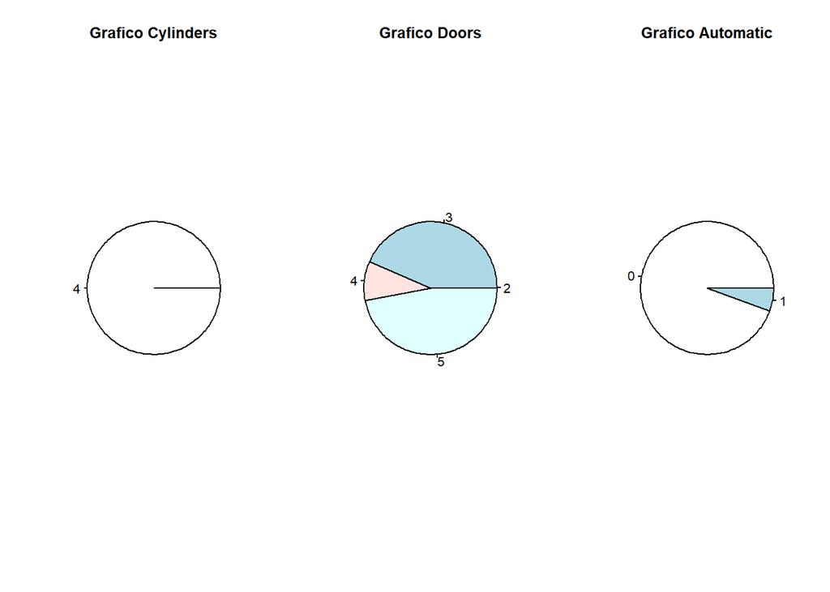

```r
par(mfrow=c(1,3))

valur = table(df0$Cylinders)
pie(x = valur, main="Grafico Cylinders")

valur = table(df0$Doors)
pie(x = valur, main="Grafico Doors")

valur = table(df0$Automatic)
pie(x = valur, main="Grafico Automatic")
```

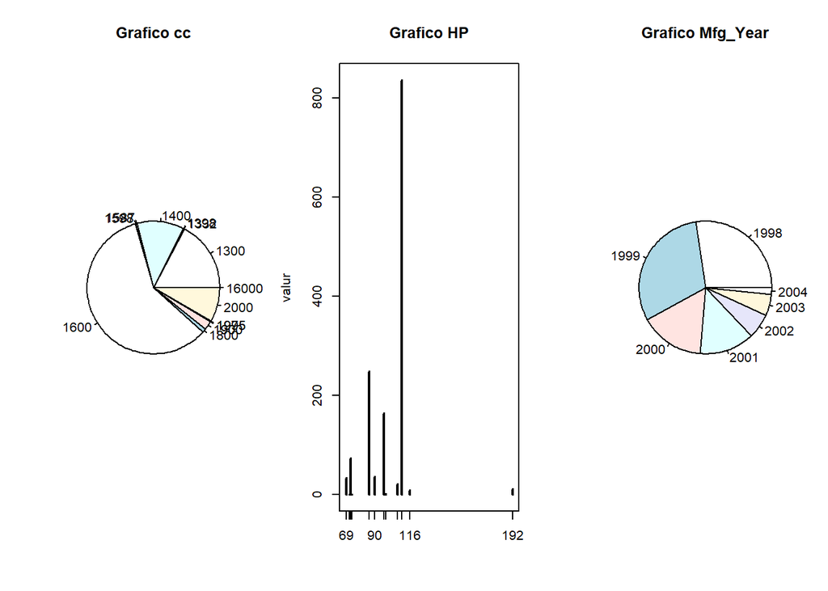

```r
par(mfrow=c(1,3))

valur = table(df0$cc)
pie(x = valur, main="Grafico cc") #HAY UNO CON CILINDRADA 16000

valur = table(df0$HP)
plot(x = valur, main="Grafico HP") #VER EL UNICO CON 192HP, ES DEPORTIVO?

valur = table(df0$Mfg_Year)
pie(x = valur, main="Grafico Mfg_Year")
```

### Encoding de atributo Fuel_type

- El atributo Fuel_type es de tipo char, y representa una categoria con varios posibles valores, por lo tanto es necesario realizar un procedimiento de encoding. Tambien es recomendable eliminar una de los columnas producto del enconding para evitar problemas de colinealidad.

```r
xi <- dummy_cols(df0, select_columns = "Fuel_Type")
xi$Fuel_Type <- NULL
```

```r
df1 <- xi
```

### Mutación del dataset

- Considero que el atributo Id no es caracteristico de cada instancia, por lo tanto considero reducir el dataSet.
- Considero que el atributo Model no es representativo de cada instancia, dado que es una descricion compuesta a partir de datos referentes a otros atributos.
- Se elimina del dataset el atributo cylinders porque es un valor constante que no es significativo.
- Se elimina las columnas cd player y radio cassete, por ser considerados como derivados del atributo radio.

```r
df1$Id <- NULL
df1$Model <- NULL
df1$Mfg_Month <- NULL
df1$Cylinders <- NULL
df1$CD_Player <- NULL
df1$Radio_cassette  <- NULL
```

```r
df2 <- subset(df1)
```

```r
summary(df2)
```

```
##      Price         Age_08_04        Mfg_Year          KM
##  Min.   : 4350   Min.   : 1.00   Min.   :1998   Min.   :     1
##  1st Qu.: 8450   1st Qu.:44.00   1st Qu.:1998   1st Qu.: 43000
##  Median : 9900   Median :61.00   Median :1999   Median : 63390
##  Mean   :10731   Mean   :55.95   Mean   :2000   Mean   : 68533
##  3rd Qu.:11950   3rd Qu.:70.00   3rd Qu.:2001   3rd Qu.: 87021
##  Max.   :32500   Max.   :80.00   Max.   :2004   Max.   :243000
##        HP          Met_Color        Automatic             cc
##  Min.   : 69.0   Min.   :0.0000   Min.   :0.00000   Min.   : 1300
##  1st Qu.: 90.0   1st Qu.:0.0000   1st Qu.:0.00000   1st Qu.: 1400
##  Median :110.0   Median :1.0000   Median :0.00000   Median : 1600
##  Mean   :101.5   Mean   :0.6748   Mean   :0.05571   Mean   : 1577
##  3rd Qu.:110.0   3rd Qu.:1.0000   3rd Qu.:0.00000   3rd Qu.: 1600
##  Max.   :192.0   Max.   :1.0000   Max.   :1.00000   Max.   :16000
##      Doors           Gears       Quarterly_Tax        Weight
##  Min.   :2.000   Min.   :3.000   Min.   : 19.00   Min.   :1000
##  1st Qu.:3.000   1st Qu.:5.000   1st Qu.: 69.00   1st Qu.:1040
##  Median :4.000   Median :5.000   Median : 85.00   Median :1070
##  Mean   :4.033   Mean   :5.026   Mean   : 87.12   Mean   :1072
##  3rd Qu.:5.000   3rd Qu.:5.000   3rd Qu.: 85.00   3rd Qu.:1085
##  Max.   :5.000   Max.   :6.000   Max.   :283.00   Max.   :1615
##  Mfr_Guarantee    BOVAG_Guarantee  Guarantee_Period      ABS
##  Min.   :0.0000   Min.   :0.0000   Min.   : 3.000   Min.   :0.0000
##  1st Qu.:0.0000   1st Qu.:1.0000   1st Qu.: 3.000   1st Qu.:1.0000
##  Median :0.0000   Median :1.0000   Median : 3.000   Median :1.0000
##  Mean   :0.4095   Mean   :0.8955   Mean   : 3.815   Mean   :0.8134
##  3rd Qu.:1.0000   3rd Qu.:1.0000   3rd Qu.: 3.000   3rd Qu.:1.0000
##  Max.   :1.0000   Max.   :1.0000   Max.   :36.000   Max.   :1.0000
##     Airbag_1         Airbag_2          Airco        Automatic_airco
##  Min.   :0.0000   Min.   :0.0000   Min.   :0.0000   Min.   :0.00000
##  1st Qu.:1.0000   1st Qu.:0.0000   1st Qu.:0.0000   1st Qu.:0.00000
##  Median :1.0000   Median :1.0000   Median :1.0000   Median :0.00000
##  Mean   :0.9708   Mean   :0.7228   Mean   :0.5084   Mean   :0.05641
##  3rd Qu.:1.0000   3rd Qu.:1.0000   3rd Qu.:1.0000   3rd Qu.:0.00000
##  Max.   :1.0000   Max.   :1.0000   Max.   :1.0000   Max.   :1.00000
##  Boardcomputer     Central_Lock    Powered_Windows Power_Steering
##  Min.   :0.0000   Min.   :0.0000   Min.   :0.000   Min.   :0.0000
##  1st Qu.:0.0000   1st Qu.:0.0000   1st Qu.:0.000   1st Qu.:1.0000
##  Median :0.0000   Median :1.0000   Median :1.000   Median :1.0000
##  Mean   :0.2946   Mean   :0.5801   Mean   :0.562   Mean   :0.9777
```

[output cut: 8 more lines]

```
##  Max.   :1.0000   Max.   :1.000   Max.   :1.0000   Max.   :1.0000
##   Metallic_Rim       Tow_Bar       Fuel_Type_Diesel Fuel_Type_Petrol
##  Min.   :0.0000   Min.   :0.0000   Min.   :0.0000   Min.   :0.0000
##  1st Qu.:0.0000   1st Qu.:0.0000   1st Qu.:0.0000   1st Qu.:1.0000
##  Median :0.0000   Median :0.0000   Median :0.0000   Median :1.0000
##  Mean   :0.2047   Mean   :0.2779   Mean   :0.1079   Mean   :0.8802
##  3rd Qu.:0.0000   3rd Qu.:1.0000   3rd Qu.:0.0000   3rd Qu.:1.0000
##  Max.   :1.0000   Max.   :1.0000   Max.   :1.0000   Max.   :1.0000
##  Fuel_Type_CNG
##  Min.   :0.00000
##  1st Qu.:0.00000
##  Median :0.00000
##  Mean   :0.01184
##  3rd Qu.:0.00000
##  Max.   :1.00000
```

### Hay Colinealidad?

```r
df_aux_corr = select_if(df2, is.numeric)
data_correlation <- cor(df_aux_corr)
```

- Este mapa de calor indica que hay una fuerte relacion entre Price y : Age_08_04, Mfg_year, KM, Weight.

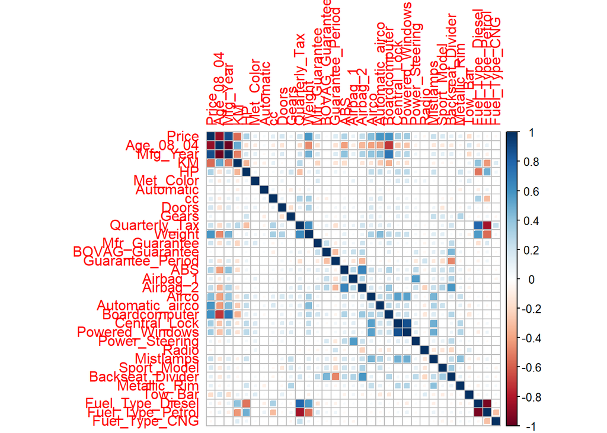

```r
#Plot de las Correlaciones
corrplot(data_correlation, method = "square", type="full")
```

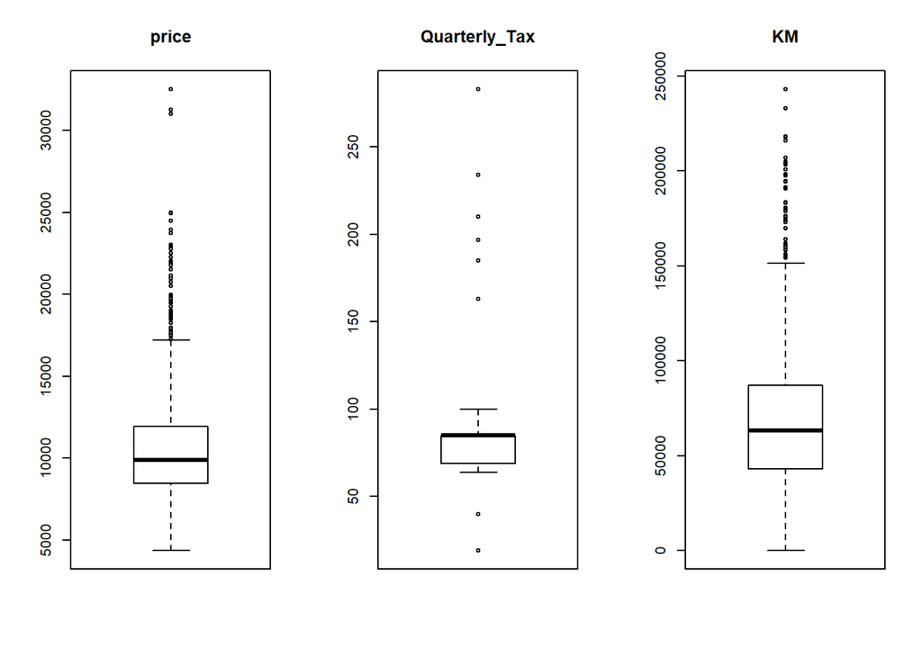

```r
par(mfrow=c(1,3))
boxplot(df2$Price, main="price")
boxplot(df2$Quarterly_Tax, main="Quarterly_Tax")
boxplot(df2$KM, main="KM")
```

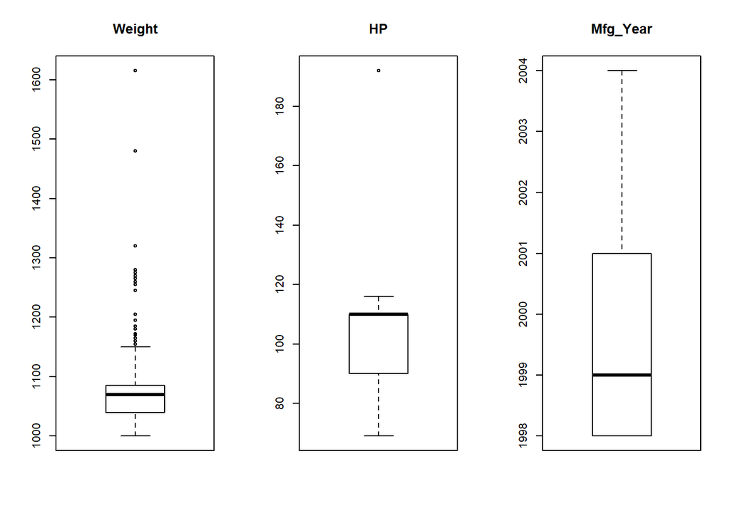

```r
par(mfrow=c(1,3))
boxplot(df2$Weight, main="Weight")
boxplot(df2$HP, main="HP")
boxplot(df2$Mfg_Year, main="Mfg_Year")
```

### Tratamiento de Outliers

- El atributo CC presenta un outlier(valor atípico) de CC = 16000. No es un valor coherente con el contexto de un vehiculo Toyota Corolla. Considero que probablemente fue un error y decido elimiarlo del modelo.

```r
df4 = subset(df2, df2$cc != 16000)
```

- El atributo Guarantee_Period presenta un outlier de Guarantee_Period = 13. No es un valor coherente con el contexto de un vehiculo Toyota Corolla (considerando los valores anteriores). Considero que probablemente fue un error y decido elimiarlo del modelo.

```r
df5_0 = subset(df4, df4$Guarantee_Period != 13)
```

- El atributo KM presenta un outliers para valores superiores a 150000. Si bien son valores coherentes dentro del contexto de vehiculos, al estar la mayor concentracion de los vehiculos dentro del intervalor 40k y 150k. Considero removerlo del modelo.

```r
df5_1 = subset(df5_0, df5_0$KM < 150000)
```

```r
df5_3 = subset(df5_1, df5_1$Weight < 1150)
```

```r
df5_4 = subset(df5_3, df5_3$HP > 85 & df5_3$Age_08_04 >= 30)
```

```r
df5 = subset(df5_4, df5_4$Price < 15000 & df5_4$Price > 6000)
```

- Este atributo presenta un outlier(valor atípico) de HP = 192. Si bien, existe un modelo de Toyota Corolla con ese valor de HP, y es un valor correcto, decidí excluirlo del modelo dado que es un caso particular.

```r
df6 = subset(df5, df5$HP != 192)
```

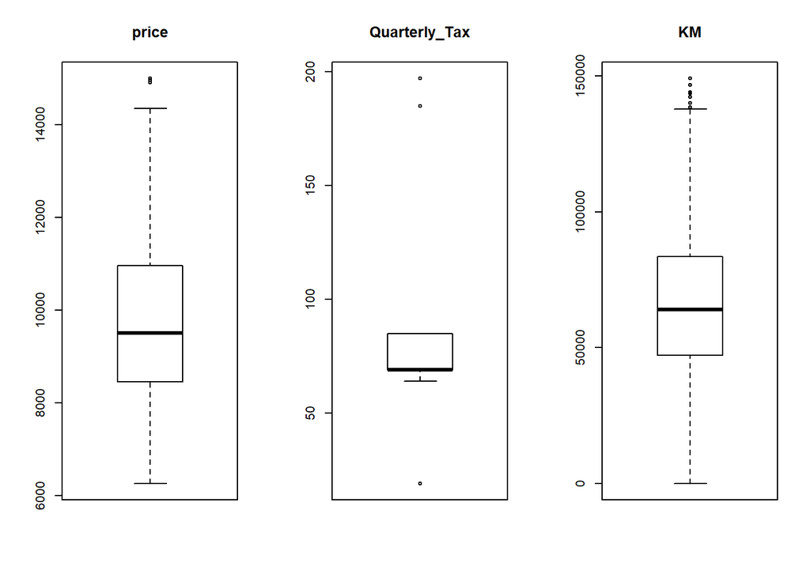

```r
par(mfrow=c(1,3))
boxplot(df6$Price, main="price")
boxplot(df6$Quarterly_Tax, main="Quarterly_Tax")
boxplot(df6$KM, main="KM")
```

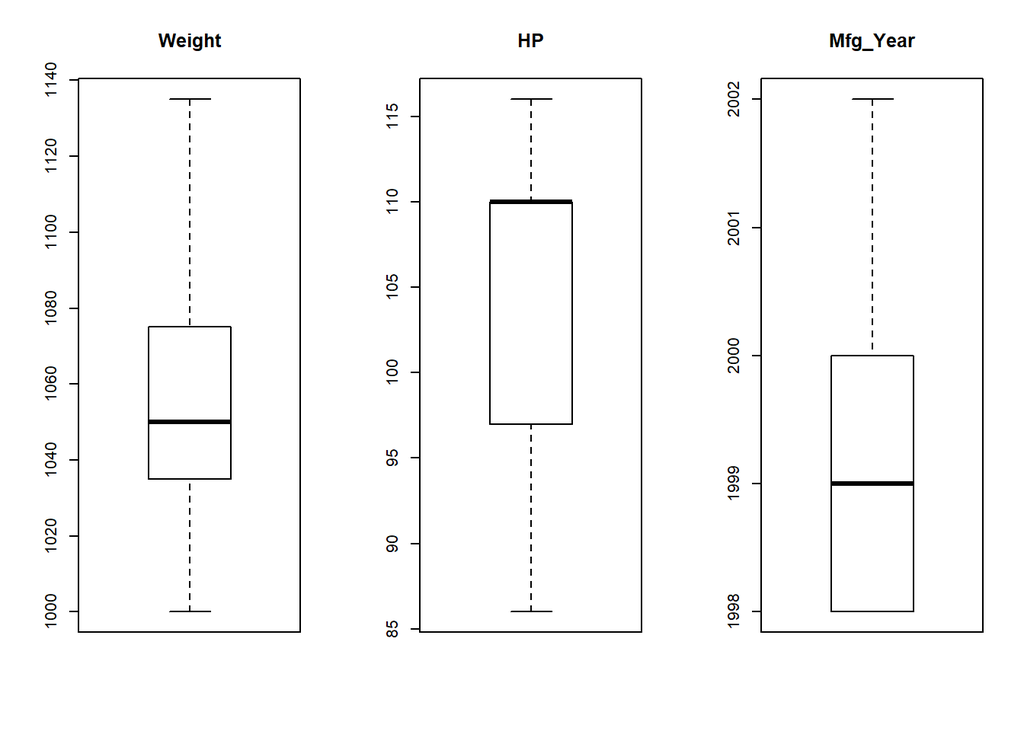

```r
par(mfrow=c(1,3))
boxplot(df6$Weight, main="Weight")
boxplot(df6$HP, main="HP")
boxplot(df6$Mfg_Year, main="Mfg_Year")
```

### Modelo de Regresión Lineal

- En primera instancia evaluo un modelo de regresion lineal sobre todas las variables de dataset. Procedo a evaluar el t value de cada atributo para obtener las caracteristicas mas relevantes del modelo.
- En los residuos se observa una forma con alguna simetria pero con un sesgo hacia la derecha.
- Presenta una exactitud de 80%. Aunque, engañoso. Presenta problema de colinealidad.

```r
summary(lm(formula = df6$Price ~ ., data=df6))
```

```
##
## Call:
## lm(formula = df6$Price ~ ., data = df6)
##
## Residuals:
##      Min       1Q   Median       3Q      Max
## -2272.95  -535.57   -47.16   506.82  3088.64
##
## Coefficients: (1 not defined because of singularities)
##                    Estimate Std. Error t value Pr(>|t|)
## (Intercept)      -2.112e+06  1.947e+05 -10.849  < 2e-16 ***
## Age_08_04        -1.479e+01  7.788e+00  -1.900 0.057757 .
## Mfg_Year          1.054e+03  9.716e+01  10.844  < 2e-16 ***
## KM               -1.234e-02  1.084e-03 -11.385  < 2e-16 ***
## HP               -9.756e+01  2.990e+01  -3.263 0.001138 **
## Met_Color        -5.919e+01  5.566e+01  -1.063 0.287867
## Automatic         1.773e+02  1.269e+02   1.397 0.162635
## cc                7.213e+00  2.291e+00   3.148 0.001691 **
## Doors            -1.104e+01  4.296e+01  -0.257 0.797182
## Gears             3.104e+02  1.424e+02   2.180 0.029474 *
## Quarterly_Tax     8.463e+00  2.049e+00   4.131 3.90e-05 ***
## Weight            1.175e+01  2.266e+00   5.185 2.58e-07 ***
## Mfr_Guarantee     2.709e+02  5.427e+01   4.992 6.97e-07 ***
## BOVAG_Guarantee   3.622e+02  9.879e+01   3.666 0.000258 ***
## Guarantee_Period  5.075e+01  1.548e+01   3.279 0.001076 **
## ABS               4.149e+01  9.587e+01   0.433 0.665254
## Airbag_1         -6.426e+01  1.828e+02  -0.351 0.725338
## Airbag_2         -1.828e+02  1.006e+02  -1.816 0.069574 .
## Airco             3.508e+02  6.640e+01   5.282 1.54e-07 ***
## Automatic_airco   2.044e+02  3.634e+02   0.562 0.573918
## Boardcomputer     1.921e+01  8.865e+01   0.217 0.828507
## Central_Lock      5.468e+01  1.063e+02   0.515 0.606911
## Powered_Windows   2.103e+02  1.060e+02   1.984 0.047490 *
## Power_Steering   -9.860e+00  1.986e+02  -0.050 0.960420
## Radio            -7.424e+01  7.356e+01  -1.009 0.313117
## Mistlamps         5.702e+01  8.368e+01   0.681 0.495791
## Sport_Model      -8.449e+01  7.372e+01  -1.146 0.252000
## Backseat_Divider -7.805e+01  9.960e+01  -0.784 0.433416
## Metallic_Rim      1.655e+01  7.252e+01   0.228 0.819518
## Tow_Bar          -1.194e+02  5.671e+01  -2.106 0.035416 *
## Fuel_Type_Diesel -4.700e+03  1.590e+03  -2.956 0.003185 **
## Fuel_Type_Petrol  1.192e+03  3.388e+02   3.520 0.000450 ***
## Fuel_Type_CNG            NA         NA      NA       NA
## ---
## Signif. codes:  0 '***' 0.001 '**' 0.01 '*' 0.05 '.' 0.1 ' ' 1
##
## Residual standard error: 825 on 1070 degrees of freedom
## Multiple R-squared:  0.7983, Adjusted R-squared:  0.7925
## F-statistic: 136.6 on 31 and 1070 DF,  p-value: < 2.2e-16
```

- Se desarrolla un modelo de regresion lineal empleando solamente variables que influyen fuertemente sobre el resultado. Brinda una respuesta satisfactoria en un 75% de los casos.

```r
linearMod <- lm(formula = df6$Price ~  df6$KM
                + df6$Mfg_Year
                + df6$Mfr_Guarantee
                + df6$Airco
                , data=df6)

summary(linearMod)
```

```
##
## Call:
## lm(formula = df6$Price ~ df6$KM + df6$Mfg_Year + df6$Mfr_Guarantee +
##     df6$Airco, data = df6)
##
## Residuals:
##      Min       1Q   Median       3Q      Max
## -2633.59  -647.28   -14.15   588.18  3060.59
##
## Coefficients:
##                     Estimate Std. Error t value Pr(>|t|)
## (Intercept)       -2.381e+06  6.067e+04 -39.249  < 2e-16 ***
## df6$KM            -1.188e-02  1.136e-03 -10.459  < 2e-16 ***
## df6$Mfg_Year       1.196e+03  3.033e+01  39.429  < 2e-16 ***
## df6$Mfr_Guarantee  3.068e+02  5.622e+01   5.456 6.02e-08 ***
## df6$Airco          7.103e+02  5.710e+01  12.440  < 2e-16 ***
## ---
## Signif. codes:  0 '***' 0.001 '**' 0.01 '*' 0.05 '.' 0.1 ' ' 1
##
## Residual standard error: 907.2 on 1097 degrees of freedom
## Multiple R-squared:   0.75,  Adjusted R-squared:  0.7491
## F-statistic: 822.7 on 4 and 1097 DF,  p-value: < 2.2e-16
```

- No presenta problemas de colinealidad dado que el valor VIF es cercano a la unidad.

```r
vif(linearMod)
```

```
##            df6$KM      df6$Mfg_Year df6$Mfr_Guarantee         df6$Airco
##          1.224809          1.344009          1.038626          1.080906
```

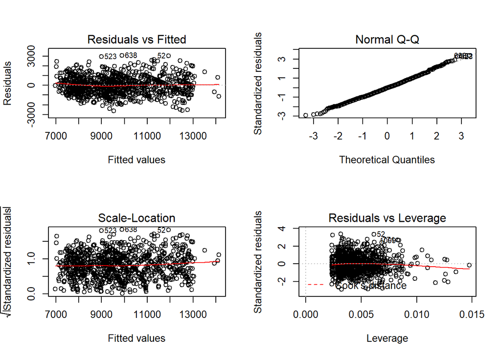

```r
par(mfrow=c(2,2))
plot(linearMod)
```

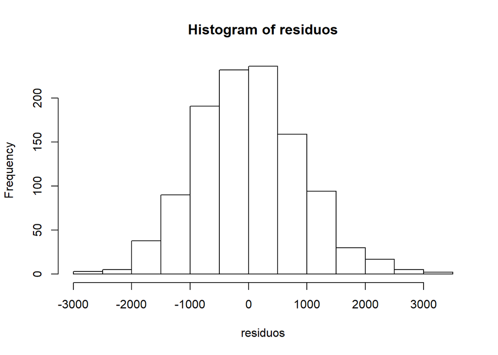

```r
residuos = resid(linearMod)
hist(residuos)
```